# Lab 7: Decision Tree Classification on the Iris Dataset

## Import Required Libraries

```python
import numpy as np
import pandas as pd
import matplotlib.pyplot as plt
import seaborn as sns

from sklearn.datasets import load_iris
from sklearn.model_selection import train_test_split, StratifiedKFold, cross_validate
from sklearn.tree import DecisionTreeClassifier, plot_tree
from sklearn.metrics import accuracy_score, confusion_matrix, classification_report

sns.set_theme(style="whitegrid")
pd.set_option("display.max_colwidth", None)
```

## Task 1: Dataset Exploration

```python
# Load the Iris dataset as pandas objects
iris = load_iris(as_frame=True)
X = iris.data
y = iris.target

# Combine features and readable target labels for exploration
iris_df = X.copy()
iris_df["target"] = y
iris_df["species"] = y.map(dict(enumerate(iris.target_names)))

print(f"Number of samples: {X.shape[0]}")
print(f"Number of features: {X.shape[1]}")
print("\nFeature names:")
for feature in iris.feature_names:
    print(f"- {feature}")
print("\nTarget classes:", list(iris.target_names))

print("\nFirst five records:")
display(iris_df.head())
```

```
Number of samples: 150
Number of features: 4

Feature names:
- sepal length (cm)
- sepal width (cm)
- petal length (cm)
- petal width (cm)

Target classes: [np.str_('setosa'), np.str_('versicolor'), np.str_('virginica')]

First five records:
```

|  | sepal length (cm) | sepal width (cm) | petal length (cm) | petal width (cm) | target | species |
| --- | --- | --- | --- | --- | --- | --- |
| 0 | 5.1 | 3.5 | 1.4 | 0.2 | 0 | setosa |
| 1 | 4.9 | 3.0 | 1.4 | 0.2 | 0 | setosa |
| 2 | 4.7 | 3.2 | 1.3 | 0.2 | 0 | setosa |
| 3 | 4.6 | 3.1 | 1.5 | 0.2 | 0 | setosa |
| 4 | 5.0 | 3.6 | 1.4 | 0.2 | 0 | setosa |

```
Class distribution:
```

|  | Class | Number of samples |
| --- | --- | --- |
| 0 | setosa | 50 |
| 1 | versicolor | 50 |
| 2 | virginica | 50 |

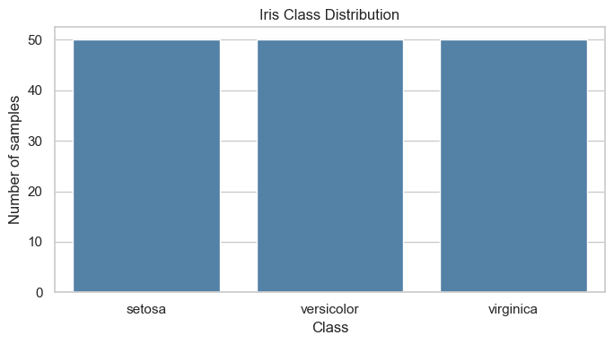

```python
class_distribution = (
    iris_df["species"]
    .value_counts()
    .reindex(iris.target_names)
    .rename_axis("Class")
    .reset_index(name="Number of samples")
)
print("Class distribution:")
display(class_distribution)

plt.figure(figsize=(7, 4))
sns.countplot(data=iris_df, x="species", order=iris.target_names, color="steelblue")
plt.title("Iris Class Distribution")
plt.xlabel("Class")
plt.ylabel("Number of samples")
plt.tight_layout()
plt.show()
```

## Task 2: Data Preparation

```python
X_train, X_test, y_train, y_test = train_test_split(
    X,
    y,
    test_size=0.20,
    random_state=42,
    stratify=y
)

print("Training feature shape:", X_train.shape)
print("Testing feature shape:", X_test.shape)
print(f"Training samples: {len(X_train)} ({len(X_train) / len(X):.0%})")
print(f"Testing samples:  {len(X_test)} ({len(X_test) / len(X):.0%})")
print("\nTraining class distribution:", y_train.value_counts().sort_index().to_dict())
print("Testing class distribution: ", y_test.value_counts().sort_index().to_dict())
```

```
Training feature shape: (120, 4)
Testing feature shape: (30, 4)
Training samples: 120 (80%)
Testing samples:  30 (20%)

Training class distribution: {0: 40, 1: 40, 2: 40}
Testing class distribution:  {0: 10, 1: 10, 2: 10}
```

The dataset is divided so the model learns patterns from the training set, while the testing set evaluates its performance on unseen data. This provides a more realistic measure of generalization and helps detect overfitting.

## Task 3: Building a Decision Tree Classifier

```python
# Train the default Decision Tree model
dt_default = DecisionTreeClassifier(random_state=42)
dt_default.fit(X_train, y_train)

# Predict the test labels
y_pred = dt_default.predict(X_test)

prediction_preview = pd.DataFrame({
    "Actual": [iris.target_names[i] for i in y_test.to_numpy()],
    "Predicted": [iris.target_names[i] for i in y_pred]
}, index=y_test.index).sort_index()

print("Predicted class labels:")
print(y_pred)
print("\nActual and predicted classes:")
display(prediction_preview)
```

```
Predicted class labels:
[0 2 1 1 0 1 0 0 2 1 2 2 2 1 0 0 0 1 1 2 0 2 1 1 2 2 1 0 2 0]

Actual and predicted classes:
```

|  | Actual | Predicted |
| --- | --- | --- |
| 7 | setosa | setosa |
| 10 | setosa | setosa |
| 14 | setosa | setosa |
| 18 | setosa | setosa |
| 20 | setosa | setosa |
| 22 | setosa | setosa |
| 28 | setosa | setosa |
| 38 | setosa | setosa |
| 42 | setosa | setosa |
| 49 | setosa | setosa |
| 51 | versicolor | versicolor |
| 56 | versicolor | versicolor |
| 57 | versicolor | versicolor |
| 58 | versicolor | versicolor |
| 63 | versicolor | versicolor |
| 69 | versicolor | versicolor |
| 75 | versicolor | versicolor |
| 77 | versicolor | virginica |
| 84 | versicolor | versicolor |
| 93 | versicolor | versicolor |
| 104 | virginica | virginica |
| 107 | virginica | virginica |
| 116 | virginica | virginica |
| 127 | virginica | virginica |
| 132 | virginica | virginica |
| 134 | virginica | versicolor |
| 138 | virginica | virginica |
| 140 | virginica | virginica |
| 141 | virginica | virginica |
| 147 | virginica | virginica |

```
Accuracy Score: 0.9333 (93.33%)

Confusion Matrix:
[[10  0  0]
 [ 0  9  1]
 [ 0  1  9]]

Classification Report:
              precision    recall  f1-score   support

      setosa       1.00      1.00      1.00        10
  versicolor       0.90      0.90      0.90        10
   virginica       0.90      0.90      0.90        10

    accuracy                           0.93        30
   macro avg       0.93      0.93      0.93        30
weighted avg       0.93      0.93      0.93        30
```

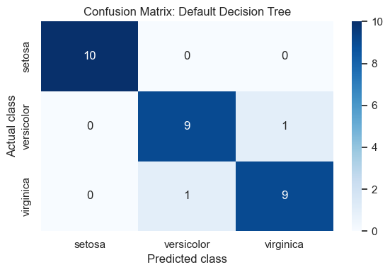

```python
default_accuracy = accuracy_score(y_test, y_pred)
default_cm = confusion_matrix(y_test, y_pred)

print(f"Accuracy Score: {default_accuracy:.4f} ({default_accuracy:.2%})")
print("\nConfusion Matrix:")
print(default_cm)
print("\nClassification Report:")
print(classification_report(y_test, y_pred, target_names=iris.target_names))

plt.figure(figsize=(6, 4))
sns.heatmap(
    default_cm,
    annot=True,
    fmt="d",
    cmap="Blues",
    xticklabels=iris.target_names,
    yticklabels=iris.target_names
)
plt.title("Confusion Matrix: Default Decision Tree")
plt.xlabel("Predicted class")
plt.ylabel("Actual class")
plt.tight_layout()
plt.show()
```

## Task 3A: Stratified 5-Fold Cross-Validation

A single train-test split can be unusually easy or difficult, especially with a small dataset. Stratified 5-fold cross-validation evaluates the model five times while preserving the class proportions in every fold. Each sample is used for validation once and for training four times.

```python
cv = StratifiedKFold(n_splits=5, shuffle=True, random_state=42)

cv_models = {
    "Unrestricted tree": DecisionTreeClassifier(random_state=42),
    "Depth-3 tree": DecisionTreeClassifier(max_depth=3, random_state=42)
}

fold_rows = []
summary_rows = []

for model_name, model in cv_models.items():
    scores = cross_validate(
        model,
        X,
        y,
        cv=cv,
        scoring="accuracy",
        return_train_score=True
    )

    for fold, (train_score, validation_score) in enumerate(
        zip(scores["train_score"], scores["test_score"]), start=1
    ):
        fold_rows.append({
            "Model": model_name,
            "Fold": fold,
            "Training Accuracy": train_score,
            "Validation Accuracy": validation_score
        })

    mean_train = scores["train_score"].mean()
    mean_validation = scores["test_score"].mean()
    summary_rows.append({
        "Model": model_name,
        "Mean Training Accuracy": mean_train,
        "Mean Validation Accuracy": mean_validation,
        "Validation Std. Dev.": scores["test_score"].std(ddof=1),
        "Train-Validation Gap": mean_train - mean_validation
    })

fold_results = pd.DataFrame(fold_rows)
cv_summary = pd.DataFrame(summary_rows)

print("Accuracy in each fold:")
display(
    fold_results.style.format({
        "Training Accuracy": "{:.2%}",
        "Validation Accuracy": "{:.2%}"
    })
)

print("Cross-validation summary:")
display(
    cv_summary.style.format({
        "Mean Training Accuracy": "{:.2%}",
        "Mean Validation Accuracy": "{:.2%}",
        "Validation Std. Dev.": "{:.2%}",
        "Train-Validation Gap": "{:.2%}"
    })
)
```

```
Accuracy in each fold:
```

|  | Model | Fold | Training Accuracy | Validation Accuracy |
| --- | --- | --- | --- | --- |
| 0 | Unrestricted tree | 1 | 100.00% | 100.00% |
| 1 | Unrestricted tree | 2 | 100.00% | 96.67% |
| 2 | Unrestricted tree | 3 | 100.00% | 93.33% |
| 3 | Unrestricted tree | 4 | 100.00% | 96.67% |
| 4 | Unrestricted tree | 5 | 100.00% | 90.00% |
| 5 | Depth-3 tree | 1 | 96.67% | 96.67% |
| 6 | Depth-3 tree | 2 | 97.50% | 96.67% |
| 7 | Depth-3 tree | 3 | 98.33% | 93.33% |
| 8 | Depth-3 tree | 4 | 96.67% | 100.00% |
| 9 | Depth-3 tree | 5 | 98.33% | 93.33% |

```
Cross-validation summary:
```

|  | Model | Mean Training Accuracy | Mean Validation Accuracy | Validation Std. Dev. | Train-Validation Gap |
| --- | --- | --- | --- | --- | --- |
| 0 | Unrestricted tree | 100.00% | 95.33% | 3.80% | 4.67% |
| 1 | Depth-3 tree | 97.50% | 96.00% | 2.79% | 1.50% |

### Cross-Validation Interpretation

- The **unrestricted tree** obtains **100.00% mean training accuracy** and **95.33% mean validation accuracy** with a standard deviation of **3.80%**. Its train-validation gap is **4.67 percentage points**.
- The **depth-3 tree** obtains **97.50% mean training accuracy** and **96.00% mean validation accuracy** with a standard deviation of **2.79%**. Its gap is only **1.50 percentage points**.

## Task 4: Visualizing the Decision Tree

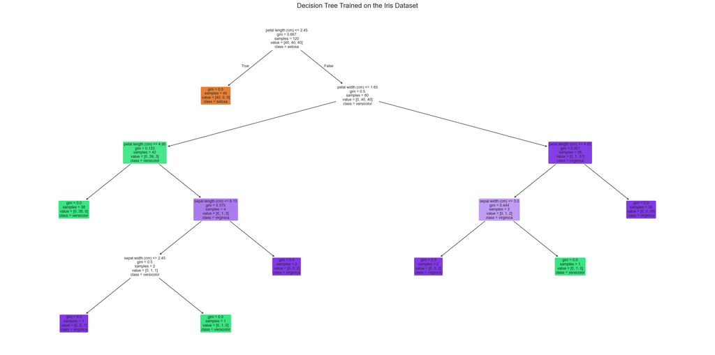

```python
plt.figure(figsize=(24, 12))
plot_tree(
    dt_default,
    feature_names=iris.feature_names,
    class_names=iris.target_names,
    filled=True,
    rounded=True,
    fontsize=9
)
plt.title("Decision Tree Trained on the Iris Dataset", fontsize=16)
plt.tight_layout()
plt.show()
```

```python
tree = dt_default.tree_
root_feature_index = tree.feature[0]
root_feature = iris.feature_names[root_feature_index]
root_threshold = tree.threshold[0]

internal_node_ids = [
    node_id for node_id in range(tree.node_count)
    if tree.children_left[node_id] != tree.children_right[node_id]
]
leaf_node_ids = [
    node_id for node_id in range(tree.node_count)
    if tree.children_left[node_id] == tree.children_right[node_id]
]

print(f"Root node (node 0): {root_feature} <= {root_threshold:.2f}")
print(f"Total splitting/internal nodes (including root): {len(internal_node_ids)}")
print(f"Other internal nodes: {len(internal_node_ids) - 1}")
print("Internal node IDs:", internal_node_ids)
print(f"Leaf nodes: {len(leaf_node_ids)}")
print("Leaf node IDs:", leaf_node_ids)
print(f"Maximum depth: {dt_default.get_depth()}")
print(f"Feature selected for first split: {root_feature}")
```

```
Root node (node 0): petal length (cm) <= 2.45
Total splitting/internal nodes (including root): 7
Other internal nodes: 6
Internal node IDs: [0, 2, 3, 5, 6, 10, 11]
Leaf nodes: 8
Leaf node IDs: [1, 4, 7, 8, 9, 12, 13, 14]
Maximum depth: 5
Feature selected for first split: petal length (cm)
```

### Interpretation of the Tree

- **Root node:** Node 0, which tests petal length (cm) <= 2.45.
- **Internal nodes:** There are 7 splitting nodes including the root, or 6 additional internal nodes below it. These nodes contain further feature tests.
- **Leaf nodes:** There are 8 terminal nodes. Each leaf gives the final predicted class and has no children.
- **Maximum depth:** **5**, where the root is at depth 0.
- **First split feature:** **petal length (cm)**.

It was chosen because this split produces a large reduction in Gini impurity by cleanly separating setosa, which has much shorter petals, from versicolor and virginica.